# Demand for Social and Food Reinforcement in Rats

Transparent R reproduction of Kirkman, Wan, and Hackenberg (2022)

Author

Haoran Wan

Published

July 1, 2026

## Purpose and scope

This report reproduces the session-level demand analyses reported in:

> Kirkman, C., Wan, H., & Hackenberg, T. D. (2022). A behavioral-economic analysis of demand and preference for social and food reinforcement in rats. *Learning and Motivation, 77*, 101780. https://doi.org/10.1016/j.lmot.2021.101780

The report is a computational companion to the article, not a substitute for it. The article is the scientific reference for the experimental procedure, animal-care oversight, theoretical rationale, and interpretation. These analyses re-estimate the published models from the processed session-level data and make the transformations, fit statistics, and limitations explicit.

### Study design

Four focal female Sprague-Dawley rats (R2, R4, R6, and R8) chose between a food pellet and 10 seconds of social access to a familiar partner. Fixed-ratio (FR) prices changed geometrically across sessions.

| Phase | Price manipulation | Primary question | Rats |
| --- | --- | --- | --- |
| 1 | Food FR increased; social FR = 1 | Food own-price demand and social cross-price demand | R2, R4, R6, R8 |
| 2 | Social FR increased; food FR = 1 | Social own-price demand and food cross-price demand | R2, R4, R6, R8 |
| 3 | Food and social FR increased together | Direct comparison of food and social own-price demand | R4, R6 |
| 4 | Food FR increased; no social option | Food demand without a concurrent social alternative | R4, R6 |

The analyses are descriptive model reproductions. The small number of focal rats, especially in Phases 3 and 4, does not support population-level confirmatory inference.

## Reproducibility setup

**Show analysis code**

```r
library(knitr)
library(minpack.lm)

options(
  digits = 5,
  scipen = 4,
  stringsAsFactors = FALSE
)

data_path <- "data with bl mean.csv"
stopifnot(file.exists(data_path))

dat <- read.csv(data_path, fileEncoding = "UTF-8-BOM", check.names = FALSE)

required_columns <- c(
  "cond", "subj", "socfr", "socr", "foodfr", "foodr"
)
missing_columns <- setdiff(required_columns, names(dat))
if (length(missing_columns) > 0) {
  stop("Missing required columns: ", paste(missing_columns, collapse = ", "))
}

stopifnot(
  all(dat$cond %in% 1:4),
  all(dat$subj %in% 1:4),
  all(dat$foodfr > 0),
  all(dat$foodr >= 0),
  all(dat$socr[dat$cond != 4] >= 0)
)

rat_lookup <- c("1" = 2L, "2" = 4L, "3" = 6L, "4" = 8L)
dat$rat <- unname(rat_lookup[as.character(dat$subj)])

phase_description <- c(
  "1" = "Food price varied; social FR 1",
  "2" = "Social price varied; food FR 1",
  "3" = "Food and social prices varied",
  "4" = "Food price varied; no social option"
)

cat("Input:", data_path, "\n")
```

```
Input: data with bl mean.csv
```

**Show analysis code**

```r
cat("Rows:", nrow(dat), "| Columns:", ncol(dat), "\n")
```

```
Rows: 91 | Columns: 11
```

**Show analysis code**

```r
cat("MD5:", unname(tools::md5sum(data_path)), "\n")
```

```
MD5: 7de9d76fb8063704f2fc0778b70a84b9
```

The processed input contains one row per rat, phase, and analyzed FR price after baseline aggregation. Internal subject codes 1-4 map to the published labels R2, R4, R6, and R8.

**Show analysis code**

```r
audit_rows <- do.call(
  rbind,
  lapply(split(dat, interaction(dat$cond, dat$rat, drop = TRUE)), function(g) {
    phase <- unique(g$cond)
    price <- if (phase == 2) g$socfr else g$foodfr
    data.frame(
      Phase = phase,
      Rat = paste0("R", unique(g$rat)),
      `Analyzed prices` = paste(price, collapse = ", "),
      `Rows` = nrow(g),
      check.names = FALSE
    )
  })
)
audit_rows <- audit_rows[order(audit_rows$Phase, audit_rows$Rat), ]
rownames(audit_rows) <- NULL
kable(audit_rows, align = c("c", "c", "l", "c"), caption = "Analysis input by phase and rat")
```

Analysis input by phase and rat

[output not shown]

## Models and estimands

### Own-price demand

The normalized zero-bounded exponential (ZBEn) model accommodates sessions with zero consumption:

$$\operatorname{IHS}(Q_A) = \operatorname{IHS}(Q_0)
\exp\left[-\frac{\alpha}{\operatorname{IHS}(Q_0)}Q_0P_A\right],$$

where

$$\operatorname{IHS}(Q) = \log_{10}\left(0.5Q + \sqrt{0.25Q^2 + 1}\right).$$

$Q_0$ is estimated consumption at zero price and $\alpha$ is sensitivity to price. Following the article, essential value is $EV = 1/(100\alpha)$, and $P_{max}$ is the price at which expenditure is maximal. The reported ZBEn $R^2$ reproduces GraphPad’s uncentered definition, $1 - SSE/\sum y^2$, on the IHS scale; it should not be read as the conventional proportion of centered variance explained.

### Cross-price demand

Cross-price analyses use $\log_{10}$ consumption of the fixed-price reinforcer. This transformation is necessary to reproduce Tables 3 and 4 of the article.

The linear model is

$$\log_{10}(Q_B) = \kappa P_A + \mu.$$

A positive $\kappa$ indicates substitution, a negative $\kappa$ indicates complementarity, and a value near zero indicates little systematic interaction.

The exponential model is

$$\log_{10}(Q_B) = \log_{10}(Q_{alone}) + I\exp(-\beta P_A).$$

A negative interaction term $I$ is consistent with substitution; a positive term is consistent with complementarity. The article emphasizes that these relations are context-dependent, not intrinsic properties of the reinforcers.

**Show analysis code**

```r
ihs10 <- function(q) {
  log10(0.5 * q + sqrt(0.25 * q^2 + 1))
}

inv_ihs10 <- function(z) {
  2 * sinh(log(10) * z)
}

zben_ihs <- function(price, Q0, alpha) {
  q0_ihs <- ihs10(Q0)
  q0_ihs * exp((-alpha / q0_ihs) * Q0 * price)
}

zben_quantity <- function(price, Q0, alpha) {
  inv_ihs10(zben_ihs(price, Q0, alpha))
}

calculate_pmax <- function(Q0, alpha, observed_price) {
  rate <- alpha * Q0 / ihs10(Q0)
  slope_equation <- function(price) {
    1 - price * log(10) * alpha * Q0 * exp(-rate * price)
  }
  price_grid <- exp(seq(log(1e-6), log(max(observed_price) * 100), length.out = 10000))
  values <- slope_equation(price_grid)
  crossing <- which(values[-length(values)] * values[-1] <= 0)[1]
  if (is.na(crossing)) return(NA_real_)
  uniroot(slope_equation, c(price_grid[crossing], price_grid[crossing + 1]))$root
}

fit_zben <- function(g, price_col, quantity_col) {
  price <- g[[price_col]]
  quantity <- g[[quantity_col]]
  y <- ihs10(quantity)

  fit <- nlsLM(
    y ~ zben_ihs(price, Q0, alpha),
    start = list(Q0 = max(quantity), alpha = 1e-4),
    lower = c(Q0 = 1e-8, alpha = 1e-10),
    control = nls.lm.control(maxiter = 1024)
  )

  estimate <- coef(fit)
  coefficient_table <- summary(fit)$coefficients
  critical <- qt(0.975, df = length(y) - length(estimate))
  lower_ci <- estimate - critical * coefficient_table[, "Std. Error"]
  upper_ci <- estimate + critical * coefficient_table[, "Std. Error"]
  predicted <- predict(fit)

  data.frame(
    Q0 = unname(estimate["Q0"]),
    Q0_low = unname(lower_ci["Q0"]),
    Q0_high = unname(upper_ci["Q0"]),
    alpha = unname(estimate["alpha"]),
    alpha_low = unname(lower_ci["alpha"]),
    alpha_high = unname(upper_ci["alpha"]),
    EV = unname(1 / (100 * estimate["alpha"])),
    Pmax = unname(calculate_pmax(estimate["Q0"], estimate["alpha"], price)),
    R2 = 1 - sum((y - predicted)^2) / sum(y^2)
  )
}
```

## Own-price results

**Show analysis code**

```r
own_specs <- data.frame(
  phase = c(1, 2, 3, 3, 4),
  commodity = c("Food", "Social", "Food", "Social", "Food"),
  price_col = c("foodfr", "socfr", "foodfr", "socfr", "foodfr"),
  quantity_col = c("foodr", "socr", "foodr", "socr", "foodr")
)

own_results <- do.call(rbind, lapply(seq_len(nrow(own_specs)), function(i) {
  spec <- own_specs[i, ]
  phase_data <- dat[dat$cond == spec$phase, ]
  do.call(rbind, lapply(split(phase_data, phase_data$subj), function(g) {
    cbind(
      data.frame(
        Phase = spec$phase,
        Commodity = spec$commodity,
        Rat = unique(g$rat)
      ),
      fit_zben(g, spec$price_col, spec$quantity_col)
    )
  }))
}))
rownames(own_results) <- NULL

own_display <- own_results[, c("Phase", "Commodity", "Rat", "Q0", "alpha", "EV", "Pmax", "R2")]
own_display$Rat <- paste0("R", own_display$Rat)
own_display$Q0 <- round(own_display$Q0, 2)
own_display$alpha <- formatC(own_display$alpha, format = "e", digits = 2)
own_display$EV <- round(own_display$EV, 2)
own_display$Pmax <- round(own_display$Pmax, 2)
own_display$R2 <- round(own_display$R2, 3)

kable(
  own_display,
  align = c("c", "l", "c", "r", "r", "r", "r", "r"),
  caption = "Re-estimated ZBEn parameters. R2 uses the article's uncentered definition."
)
```

Re-estimated ZBEn parameters. R2 uses the article’s uncentered definition.

| Phase | Commodity | Rat | Q0 | alpha | EV | Pmax | R2 |
| --- | --- | --- | --- | --- | --- | --- | --- |
| 1 | Food | R2 | 177.75 | 4.55e-04 | 21.96 | 6.87 | 0.987 |
| 1 | Food | R4 | 260.45 | 1.17e-04 | 85.42 | 17.84 | 0.994 |
| 1 | Food | R6 | 393.35 | 2.87e-04 | 34.83 | 4.72 | 0.980 |
| 1 | Food | R8 | 217.58 | 1.92e-04 | 52.20 | 13.18 | 0.989 |
| 2 | Social | R2 | 36.60 | 4.07e-03 | 2.45 | 4.45 | 0.960 |
| 2 | Social | R4 | 67.85 | 2.82e-03 | 3.55 | 3.16 | 0.950 |
| 2 | Social | R6 | 15.31 | 1.08e-02 | 0.92 | 6.46 | 0.977 |
| 2 | Social | R8 | 48.44 | 4.24e-03 | 2.36 | 3.08 | 0.968 |
| 3 | Food | R4 | 159.78 | 5.92e-05 | 169.01 | 59.23 | 0.997 |
| 3 | Food | R6 | 195.92 | 1.35e-04 | 73.89 | 20.85 | 0.999 |
| 3 | Social | R4 | 64.05 | 1.45e-03 | 6.91 | 6.56 | 0.990 |
| 3 | Social | R6 | 55.45 | 4.77e-03 | 2.10 | 2.34 | 0.968 |
| 4 | Food | R4 | 273.15 | 5.58e-05 | 179.31 | 35.62 | 0.998 |
| 4 | Food | R6 | 193.25 | 1.31e-04 | 76.28 | 21.84 | 0.998 |

### Check against published point estimates

**Show analysis code**

```r
published_own <- data.frame(
  Phase = c(rep(1, 4), rep(2, 4), 3, 3, 3, 3, 4, 4),
  Commodity = c(rep("Food", 4), rep("Social", 4), "Food", "Food", "Social", "Social", "Food", "Food"),
  Rat = c(2, 4, 6, 8, 2, 4, 6, 8, 4, 6, 4, 6, 4, 6),
  published_Q0 = c(177.74, 260.45, 393.35, 217.58, 36.60, 67.85, 15.31, 48.44, 159.78, 195.92, 64.05, 55.45, 273.15, 193.25),
  published_alpha = c(4.55e-4, 1.17e-4, 2.87e-4, 1.92e-4, 4.07e-3, 2.82e-3, 1.08e-2, 4.24e-3, 5.92e-5, 1.35e-4, 1.45e-3, 4.77e-3, 5.58e-5, 1.31e-4)
)

benchmark <- merge(own_results, published_own, by = c("Phase", "Commodity", "Rat"))
benchmark$Q0_relative_error <- abs(benchmark$Q0 - benchmark$published_Q0) / benchmark$published_Q0
benchmark$alpha_relative_error <- abs(benchmark$alpha - benchmark$published_alpha) / benchmark$published_alpha

benchmark_display <- data.frame(
  Phase = benchmark$Phase,
  Commodity = benchmark$Commodity,
  Rat = paste0("R", benchmark$Rat),
  `Q0: reproduced` = round(benchmark$Q0, 3),
  `Q0: published` = benchmark$published_Q0,
  `alpha: reproduced` = formatC(benchmark$alpha, format = "e", digits = 3),
  `alpha: published` = formatC(benchmark$published_alpha, format = "e", digits = 3),
  check.names = FALSE
)

kable(benchmark_display, caption = "Point-estimate check against Table 2 of the published article")
```

Point-estimate check against Table 2 of the published article

| Phase | Commodity | Rat | Q0: reproduced | Q0: published | alpha: reproduced | alpha: published |
| --- | --- | --- | --- | --- | --- | --- |
| 1 | Food | R2 | 177.745 | 177.74 | 4.553e-04 | 4.550e-04 |
| 1 | Food | R4 | 260.448 | 260.45 | 1.171e-04 | 1.170e-04 |
| 1 | Food | R6 | 393.353 | 393.35 | 2.871e-04 | 2.870e-04 |
| 1 | Food | R8 | 217.578 | 217.58 | 1.916e-04 | 1.920e-04 |
| 2 | Social | R2 | 36.600 | 36.60 | 4.075e-03 | 4.070e-03 |
| 2 | Social | R4 | 67.848 | 67.85 | 2.817e-03 | 2.820e-03 |
| 2 | Social | R6 | 15.308 | 15.31 | 1.082e-02 | 1.080e-02 |
| 2 | Social | R8 | 48.439 | 48.44 | 4.242e-03 | 4.240e-03 |
| 3 | Food | R4 | 159.777 | 159.78 | 5.917e-05 | 5.920e-05 |
| 3 | Food | R6 | 195.924 | 195.92 | 1.353e-04 | 1.350e-04 |
| 3 | Social | R4 | 64.046 | 64.05 | 1.448e-03 | 1.450e-03 |
| 3 | Social | R6 | 55.451 | 55.45 | 4.770e-03 | 4.770e-03 |
| 4 | Food | R4 | 273.148 | 273.15 | 5.577e-05 | 5.580e-05 |
| 4 | Food | R6 | 193.248 | 193.25 | 1.311e-04 | 1.310e-04 |

**Show analysis code**

```r
cat(
  "Maximum relative difference after accounting for published rounding:",
  sprintf(
    "Q0 = %.3f%%; alpha = %.3f%%.",
    100 * max(benchmark$Q0_relative_error),
    100 * max(benchmark$alpha_relative_error)
  )
)
```

```
Maximum relative difference after accounting for published rounding: Q0 = 0.013%; alpha = 0.251%.
```

The reproduced $Q_0$ and $\alpha$ estimates agree with the published point estimates to rounding precision. Across phases, food had higher $Q_0$ and essential value than social interaction under the studied conditions. This is a contextual comparison, not evidence that reinforcer value is fixed across procedures or motivational states.

## Cross-price results

**Show analysis code**

```r
fit_cross_linear <- function(g, price_col, quantity_col) {
  price <- g[[price_col]]
  y <- log10(g[[quantity_col]])
  fit <- lm(y ~ price)
  interval <- confint(fit)
  data.frame(
    kappa = unname(coef(fit)["price"]),
    kappa_low = interval["price", 1],
    kappa_high = interval["price", 2],
    mu = unname(coef(fit)["(Intercept)"]),
    R2 = summary(fit)$r.squared
  )
}

phase2_starts <- list(
  "1" = list(Qalone = 140.29, I = 0.0959, beta = -0.0386),
  "2" = list(Qalone = 197.07, I = 1e-9, beta = -0.56),
  "3" = list(Qalone = 168.71, I = 0.138, beta = 0.578),
  "4" = list(Qalone = 199.73, I = 1e-9, beta = -1.19)
)

fit_cross_exponential <- function(g, phase, price_col, quantity_col) {
  price <- g[[price_col]]
  quantity <- g[[quantity_col]]
  y <- log10(quantity)

  start <- if (phase == 1) {
    list(Qalone = max(quantity), I = -0.5, beta = 0.01)
  } else {
    phase2_starts[[as.character(unique(g$subj))]]
  }

  fit <- nlsLM(
    y ~ log10(Qalone) + I * exp(-beta * price),
    start = start,
    control = nls.lm.control(maxiter = 1024)
  )
  estimate <- coef(fit)
  predicted <- predict(fit)

  data.frame(
    Qalone = unname(estimate["Qalone"]),
    I = unname(estimate["I"]),
    beta = unname(estimate["beta"]),
    R2 = 1 - sum((y - predicted)^2) / sum((y - mean(y))^2)
  )
}

cross_specs <- data.frame(
  phase = c(1, 2),
  fixed_commodity = c("Social", "Food"),
  price_col = c("foodfr", "socfr"),
  quantity_col = c("socr", "foodr")
)

cross_linear <- do.call(rbind, lapply(seq_len(nrow(cross_specs)), function(i) {
  spec <- cross_specs[i, ]
  phase_data <- dat[dat$cond == spec$phase, ]
  do.call(rbind, lapply(split(phase_data, phase_data$subj), function(g) {
    cbind(
      data.frame(Phase = spec$phase, Fixed = spec$fixed_commodity, Rat = unique(g$rat)),
      fit_cross_linear(g, spec$price_col, spec$quantity_col)
    )
  }))
}))

cross_exponential <- do.call(rbind, lapply(seq_len(nrow(cross_specs)), function(i) {
  spec <- cross_specs[i, ]
  phase_data <- dat[dat$cond == spec$phase, ]
  do.call(rbind, lapply(split(phase_data, phase_data$subj), function(g) {
    cbind(
      data.frame(Phase = spec$phase, Fixed = spec$fixed_commodity, Rat = unique(g$rat)),
      fit_cross_exponential(g, spec$phase, spec$price_col, spec$quantity_col)
    )
  }))
}))
```

**Show analysis code**

```r
linear_display <- cross_linear[, c("Phase", "Fixed", "Rat", "kappa", "kappa_low", "kappa_high", "mu", "R2")]
linear_display$Rat <- paste0("R", linear_display$Rat)
for (column in c("kappa", "kappa_low", "kappa_high")) {
  linear_display[[column]] <- formatC(linear_display[[column]], format = "e", digits = 2)
}
linear_display$mu <- round(linear_display$mu, 3)
linear_display$R2 <- round(linear_display$R2, 3)
kable(linear_display, caption = "Linear cross-price models on log10 consumption")
```

Linear cross-price models on log10 consumption

|  | Phase | Fixed | Rat | kappa | kappa_low | kappa_high | mu | R2 |
| --- | --- | --- | --- | --- | --- | --- | --- | --- |
| 1 | 1 | Social | R2 | 2.16e-03 | 8.98e-04 | 3.42e-03 | 1.391 | 0.701 |
| 2 | 1 | Social | R4 | 2.33e-03 | 1.40e-03 | 3.26e-03 | 1.276 | 0.834 |
| 3 | 1 | Social | R6 | 9.93e-04 | 2.87e-04 | 1.70e-03 | 1.502 | 0.568 |
| 4 | 1 | Social | R8 | 2.43e-03 | 5.07e-04 | 4.35e-03 | 1.198 | 0.561 |
| 11 | 2 | Food | R2 | 5.24e-03 | -2.92e-03 | 1.34e-02 | 2.239 | 0.582 |
| 21 | 2 | Food | R4 | 5.22e-04 | -1.20e-02 | 1.31e-02 | 2.295 | 0.003 |
| 31 | 2 | Food | R6 | -3.98e-03 | -2.39e-02 | 1.59e-02 | 2.279 | 0.119 |
| 41 | 2 | Food | R8 | 9.90e-03 | -6.16e-03 | 2.59e-02 | 2.269 | 0.562 |

**Show analysis code**

```r
exponential_display <- cross_exponential[, c("Phase", "Fixed", "Rat", "Qalone", "I", "beta", "R2")]
exponential_display$Rat <- paste0("R", exponential_display$Rat)
exponential_display$Qalone <- round(exponential_display$Qalone, 2)
exponential_display$I <- round(exponential_display$I, 4)
exponential_display$beta <- round(exponential_display$beta, 4)
exponential_display$R2 <- round(exponential_display$R2, 3)
kable(exponential_display, caption = "Exponential cross-price models on log10 consumption")
```

Exponential cross-price models on log10 consumption

|  | Phase | Fixed | Rat | Qalone | I | beta | R2 |
| --- | --- | --- | --- | --- | --- | --- | --- |
| 1 | 1 | Social | R2 | 66.78 | -0.5300 | 0.0207 | 0.872 |
| 2 | 1 | Social | R4 | 189.60 | -1.0192 | 0.0034 | 0.849 |
| 3 | 1 | Social | R6 | 74.50 | -0.4921 | 0.0182 | 0.852 |
| 4 | 1 | Social | R8 | 66.04 | -0.6724 | 0.0089 | 0.616 |
| 11 | 2 | Food | R2 | 140.28 | 0.0960 | -0.0386 | 0.584 |
| 21 | 2 | Food | R4 | 195.08 | 0.0000 | -0.7242 | 0.059 |
| 31 | 2 | Food | R6 | 168.70 | 0.1381 | 0.5776 | 0.221 |
| 41 | 2 | Food | R8 | 199.73 | 0.0000 | -1.3207 | 0.707 |

All four Phase 1 linear slopes are positive, and all four Phase 1 exponential interaction terms are negative. Both patterns support the article’s conclusion that social interaction partially substituted for food as food became more expensive. In Phase 2, slopes are small and inconsistent in direction, and the exponential fits are weak or poorly identified. This supports the narrower conclusion that food consumption did not change systematically with social price in this procedure.

The Phase 2 exponential estimates should not be overinterpreted. With only five or six observations per rat and an approximately flat outcome, $Q_{alone}$, $I$, and $\beta$ can trade off against one another, producing local solutions and unstable confidence intervals. The linear slopes and the observed curves provide the clearer evidence.

## Demand curves

**Show analysis code**

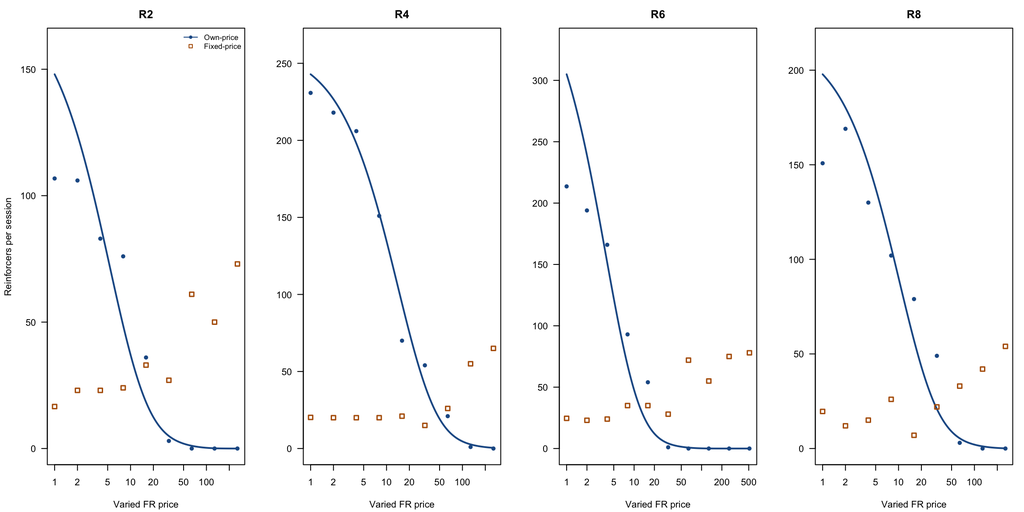

Observed own-price and cross-price consumption with fitted ZBEn own-price curves. Panels are scaled by rat to emphasize within-rat price effects.

```r
plot_phase_panels <- function(phase, own_quantity, fixed_quantity, price_col, y_label) {
  phase_data <- dat[dat$cond == phase, ]
  rats <- sort(unique(phase_data$rat))

  old_par <- par(mfrow = c(1, length(rats)), mar = c(4.2, 4.2, 2.5, 1), las = 1)
  on.exit(par(old_par), add = TRUE)

  for (index in seq_along(rats)) {
    rat_id <- rats[index]
    g <- phase_data[phase_data$rat == rat_id, ]
    own_row <- own_results[
      own_results$Phase == phase & own_results$Rat == rat_id &
        own_results$Commodity == ifelse(phase == 1, "Food", "Social"),
    ]
    grid <- exp(seq(log(min(g[[price_col]])), log(max(g[[price_col]])), length.out = 250))
    fitted <- zben_quantity(grid, own_row$Q0, own_row$alpha)
    y_max <- max(c(g[[own_quantity]], g[[fixed_quantity]], fitted), na.rm = TRUE) * 1.08

    plot(
      g[[price_col]], g[[own_quantity]],
      log = "x", pch = 16, col = "#1f5a94",
      xlab = "Varied FR price", ylab = if (index == 1) y_label else "",
      ylim = c(0, y_max), main = paste0("R", rat_id)
    )
    lines(grid, fitted, col = "#1f5a94", lwd = 2)
    points(g[[price_col]], g[[fixed_quantity]], pch = 0, col = "#b45f06", lwd = 1.5)
    if (index == 1) {
      legend(
        "topright",
        legend = c("Own-price", "Fixed-price"),
        col = c("#1f5a94", "#b45f06"), pch = c(16, 0), lty = c(1, NA),
        bty = "n", cex = 0.8
      )
    }
  }
}

plot_phase_panels(1, "foodr", "socr", "foodfr", "Reinforcers per session")
```

**Show analysis code**

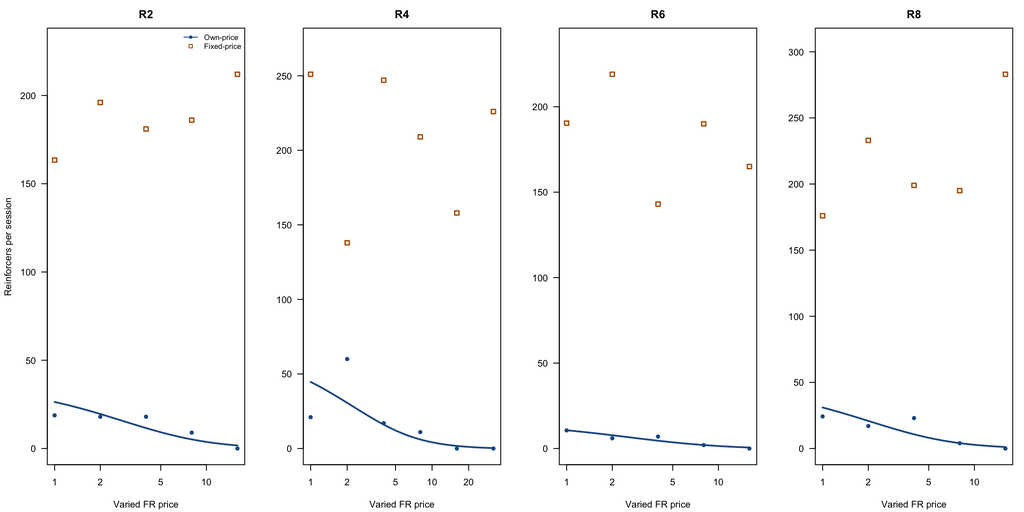

Phase 2: social own-price demand and fixed-price food consumption.

```r
plot_phase_panels(2, "socr", "foodr", "socfr", "Reinforcers per session")
```

### Food with and without a social alternative

**Show analysis code**

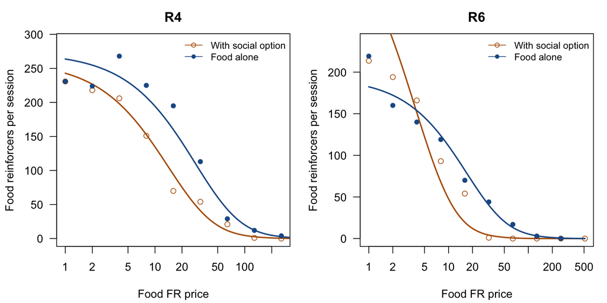

Food demand for R4 and R6 with a social alternative (Phase 1) and without one (Phase 4).

```r
old_par <- par(mfrow = c(1, 2), mar = c(4.2, 4.2, 2.5, 1), las = 1)
for (rat_id in c(4, 6)) {
  g1 <- dat[dat$cond == 1 & dat$rat == rat_id, ]
  g4 <- dat[dat$cond == 4 & dat$rat == rat_id, ]
  r1 <- own_results[own_results$Phase == 1 & own_results$Rat == rat_id & own_results$Commodity == "Food", ]
  r4 <- own_results[own_results$Phase == 4 & own_results$Rat == rat_id & own_results$Commodity == "Food", ]
  grid <- exp(seq(log(1), log(max(c(g1$foodfr, g4$foodfr))), length.out = 300))
  y_max <- max(c(g1$foodr, g4$foodr)) * 1.08

  plot(g1$foodfr, g1$foodr, log = "x", pch = 1, col = "#b45f06",
       xlab = "Food FR price", ylab = "Food reinforcers per session",
       ylim = c(0, y_max), main = paste0("R", rat_id))
  lines(grid, zben_quantity(grid, r1$Q0, r1$alpha), col = "#b45f06", lwd = 2)
  points(g4$foodfr, g4$foodr, pch = 16, col = "#1f5a94")
  lines(grid, zben_quantity(grid, r4$Q0, r4$alpha), col = "#1f5a94", lwd = 2)
  legend("topright", c("With social option", "Food alone"),
         col = c("#b45f06", "#1f5a94"), pch = c(1, 16), lty = 1, bty = "n", cex = 0.85)
}
```

**Show analysis code**

```r
par(old_par)
```

For both rats that completed Phase 4, food-alone demand had a lower $\alpha$ and higher essential value than food demand with a low-priced social alternative. This pattern is consistent with partial substitution: when social access was available, some expensive food reinforcers were traded for social reinforcers.

## Interpretation and limitations

The reproduced analyses support four study-specific conclusions:

1. Food and social interaction both functioned as reinforcers: consumption decreased as each outcome’s own price increased.
2. Under these parameters, food demand was more robust and less elastic than social demand.
3. Social interaction partially substituted for food when food price increased, whereas food consumption did not change systematically when social price increased.
4. Food demand was less elastic when food was the only available reinforcer than when a low-priced social alternative was present.

These conclusions are bounded by the design:

- Only four focal rats completed Phases 1 and 2; only R4 and R6 completed Phases 3 and 4.
- Price and total reinforcer income covaried within fixed-duration sessions, so price effects cannot be isolated from income effects.
- Social delivery was less immediate than food delivery and involved handling of the partner rat.
- The study used a partially open economy with post-session access to food and social contact.
- Cross-price labels describe context-dependent relations; they should not be treated as immutable properties of food or social interaction.
- Re-estimating a model on the same data is a reproducibility check, not an independent replication.

## Computational environment

**Show analysis code**